```r
knitr::opts_chunk$set(
  collapse = TRUE,
  comment = "#>",
  eval = module
)
```

```r
print(module)
```

```
#> [1] TRUE
```

# Benchmarking the Leiden Algorithm

In this guide we will run the Leiden algorithm in both R and Python to benchmark performance and demonstrate how the algorithm is called with `reticulate`.

We are testing this in the following environment:

```r
paste(Sys.info()[c(4, 2, 1)])
```

```
#> [1] "MacBook-Pro" "19.6.0"      "Darwin"
```

```r
R.version$version.string
```

```
#> [1] "R version 4.2.0 (2022-04-22)"
```

## Clustering with the Leiden Algorithm in R

This package allows calling the Leiden algorithm for clustering on an igraph object from R. See the Python and Java implementations for more details:

https://github.com/CWTSLeiden/networkanalysis

https://github.com/vtraag/leidenalg

It calls the Python functions to run the algorithm and passes all arguments need to them.

### Set up the python version to be called in R

## Python implementation

The python version can be installed with pip or conda:

```bash
pip uninstall -y igraph
```

```bash
pip install -U -q leidenalg
```

```bash
conda install -c vtraag leidenalg
```

It is also possible to install the python dependencies with reticulate in R.

```r
library("reticulate")
py_install("python-igraph")
py_install("leidenalg")
```

### Running in Python

We are using the following version of Python:

```python
import sys
print(sys.version)
#> 3.10.4 | packaged by conda-forge | (main, Mar 24 2022, 17:52:34) [Clang 12.0.1 ]
```

First we load the packages:

```python
import igraph as ig
print("igraph", ig.__version__)
#> igraph 0.9.10
import leidenalg as la
print("leidenalg", la.version)
#> leidenalg 0.8.10
```

Then we load the Zachary karate club example data from igraph.

```python
G = ig.Graph.Famous('Zachary')
G.summary()
#> 'IGRAPH U--- 34 78 -- '
```

```python
partition = la.find_partition(G, la.ModularityVertexPartition)
print(partition)
#> Clustering with 34 elements and 4 clusters
#> [0] 8, 9, 14, 15, 18, 20, 22, 26, 29, 30, 32, 33
#> [1] 0, 1, 2, 3, 7, 11, 12, 13, 17, 19, 21
#> [2] 23, 24, 25, 27, 28, 31
#> [3] 4, 5, 6, 10, 16
partition
#> <leidenalg.VertexPartition.ModularityVertexPartition object at 0x1243b40d0>
```

```python
partition.membership
#> [1, 1, 1, 1, 3, 3, 3, 1, 0, 0, 3, 1, 1, 1, 0, 0, 3, 1, 0, 1, 0, 1, 0, 2, 2, 2, 0, 2, 2, 0, 0, 2, 0, 0]
```

```r
partition <- py$partition$membership + 1
table(partition)
```

```
#> partition
#>  1  2  3  4
#> 12 11  6  5
```

We can plot the result in R to show it in the network. This reproduces the example in the Python leidenalg documentation.

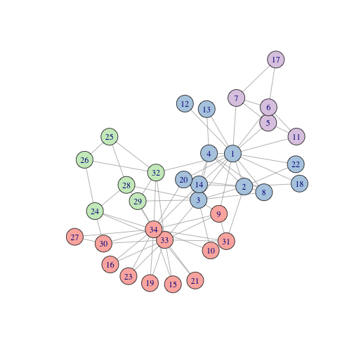

```r
library("igraph")
library("reticulate")
library("RColorBrewer")
graph_object <- graph.famous("Zachary")
node.cols <- brewer.pal(max(c(3, partition)),"Pastel1")[partition]
plot(graph_object, vertex.color = node.cols, layout=layout_with_kk)
```

We can reproduce passing arguments in this manner as well.

```python
partition = la.find_partition(G, la.CPMVertexPartition, resolution_parameter = 0.05)
print(partition)
#> Clustering with 34 elements and 2 clusters
#> [0] 0, 1, 2, 3, 4, 5, 6, 7, 9, 10, 11, 12, 13, 16, 17, 19, 21
#> [1] 8, 14, 15, 18, 20, 22, 23, 24, 25, 26, 27, 28, 29, 30, 31, 32, 33
partition
#> <leidenalg.VertexPartition.CPMVertexPartition object at 0x1243b5180>
```

```python
partition.membership
#> [0, 0, 0, 0, 0, 0, 0, 0, 1, 0, 0, 0, 0, 0, 1, 1, 0, 0, 1, 0, 1, 0, 1, 1, 1, 1, 1, 1, 1, 1, 1, 1, 1, 1]
```

```r
partition <- py$partition$membership + 1
table(partition)
```

```
#> partition
#>  1  2
#> 17 17
```

We can plot the result in R to show it in the network. This reproduces the example in the Python leidenalg documentation.

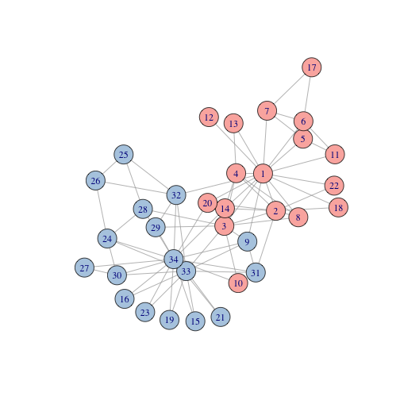

```r
graph_object <- graph.famous("Zachary")
node.cols <- brewer.pal(max(c(3, partition)),"Pastel1")[partition]
plot(graph_object, vertex.color = node.cols, layout=layout_with_kk)
```

We can run the RBC vertex method which generalises the modularity vertex partition.

```python
partition = la.find_partition(G, la.RBConfigurationVertexPartition, resolution_parameter = 1.5)
print(partition)
#> Clustering with 34 elements and 5 clusters
#> [0] 0, 1, 2, 3, 7, 11, 12, 13, 17, 19, 21
#> [1] 9, 14, 15, 18, 20, 22, 26, 29, 32, 33
#> [2] 23, 24, 25, 27, 28, 31
#> [3] 4, 5, 6, 10, 16
#> [4] 8, 30
partition
#> <leidenalg.VertexPartition.RBConfigurationVertexPartition object at 0x1243b59f0>
```

```python
partition.membership
#> [0, 0, 0, 0, 3, 3, 3, 0, 4, 1, 3, 0, 0, 0, 1, 1, 3, 0, 1, 0, 1, 0, 1, 2, 2, 2, 1, 2, 2, 1, 4, 2, 1, 1]
```

```r
partition <- py$partition$membership + 1
table(partition)
```

```
#> partition
#>  1  2  3  4  5
#> 11 10  6  5  2
```

We can plot the result in R to show it in the network.

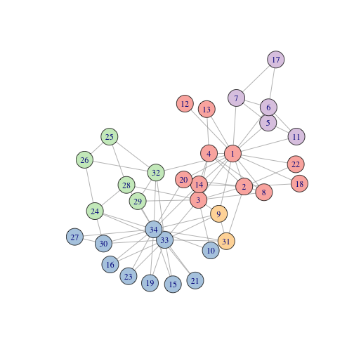

```r
graph_object <- graph.famous("Zachary")
node.cols <- brewer.pal(max(c(3, partition)),"Pastel1")[partition]
plot(graph_object, vertex.color = node.cols, layout=layout_with_kk)
```

#### Benchmarking the Python version with reticulate

```python
import time
G = ig.Graph.Famous('Zachary')
G.summary()
#> 'IGRAPH U--- 34 78 -- '
start = time.time()
for ii in range(100):
    partition = la.find_partition(G, la.ModularityVertexPartition)

end = time.time()
partition.membership
#> [1, 1, 1, 1, 3, 3, 3, 1, 0, 0, 3, 1, 1, 1, 0, 0, 3, 1, 0, 1, 0, 1, 0, 2, 2, 2, 0, 2, 2, 0, 0, 2, 0, 0]
py_time = end - start
print("leiden time:", py_time, "seconds")
#> leiden time: 0.08396506309509277 seconds
```

```bash
bash_py_time=`python -c 'import igraph as ig
import leidenalg as la
import time
G = ig.Graph.Famous("Zachary")
G.summary()
start = time.time()
for ii in range(100):
    partition = la.find_partition(G, la.ModularityVertexPartition)

end = time.time()
partition.membership
py_time = end - start
print(py_time)'`
echo $bash_py_time > bash_py_time
echo "leiden time:" $bash_py_time "seconds"
#> leiden time: 0.05826997756958008 seconds
```

```r
bash_py_time <- as.numeric(readLines("bash_py_time"))
```

We can also run the leiden algorithm in python by calling functions with reticulate:

```r
leidenalg <- import("leidenalg", delay_load = TRUE)
ig <- import("igraph", delay_load = TRUE)
G = ig$Graph$Famous('Zachary')
G$summary()
```

```
#> [1] "IGRAPH U--- 34 78 -- "
```

```r
partition = leidenalg$find_partition(G, leidenalg$ModularityVertexPartition)
partition$membership
```

```
#>  [1] 1 1 1 1 3 3 3 1 0 0 3 1 1 1 0 0 3 1 0 1 0 1 0 2 2 2 0 2 2 0 0 2 0 0
```

```r
leidenalg <- import("leidenalg", delay_load = TRUE)
ig <- import("igraph", delay_load = TRUE)
G = ig$Graph$Famous('Zachary')
G$summary()
```

```
#> [1] "IGRAPH U--- 34 78 -- "
```

```r
start <- Sys.time()
for(ii in 1:100){
  partition = leidenalg$find_partition(G, leidenalg$ModularityVertexPartition)
}
end <- Sys.time()
partition$membership
```

```
#>  [1] 1 1 1 1 3 3 3 1 0 0 3 1 1 1 0 0 3 1 0 1 0 1 0 2 2 2 0 2 2 0 0 2 0 0
```

```r
reticulate_time <- difftime(end, start)[[1]]
print(paste(c("leiden time:", reticulate_time, "seconds"), collapse = " "))
```

```
#> [1] "leiden time: 0.195164918899536 seconds"
```

## R implementation

```r
install.packages("leiden")
```

```bash
install.packages("leiden")
```

Note that these require the Python version as a dependency.

### Running in R via reticulate and igraph

We can reproduce these by running the Leiden algorithm in R using the functions in the leiden package.

We are using the following version of R:

```r
R.version.string
```

```
#> [1] "R version 4.2.0 (2022-04-22)"
```

First we load the packages:

```r
library("igraph")
library("leiden")
```

Then we load the Zachary karate club example data from igraph.

```r
G <- graph.famous("Zachary")
summary(G)
```

```
#> IGRAPH afa0bff U--- 34 78 -- Zachary
#> + attr: name (g/c)
```

#### Calling python in R via reticulate

Here run “legacy” mode to call “leidenalg” in python with the R reticulate package.

```r
partition <- leiden(G, "ModularityVertexPartition", legacy = TRUE)













































































partition
```

```
#>  [1] 2 2 2 2 4 4 4 2 1 1 4 2 2 2 1 1 4 2 1 2 1 2 1 3 3 3 1 3 3 1 1 3 1 1
```

```r
table(partition)
```

```
#> partition
#>  1  2  3  4
#> 12 11  6  5
```

We can plot the result in R to show it in the network. This reproduces the example in the Python leidenalg documentation.

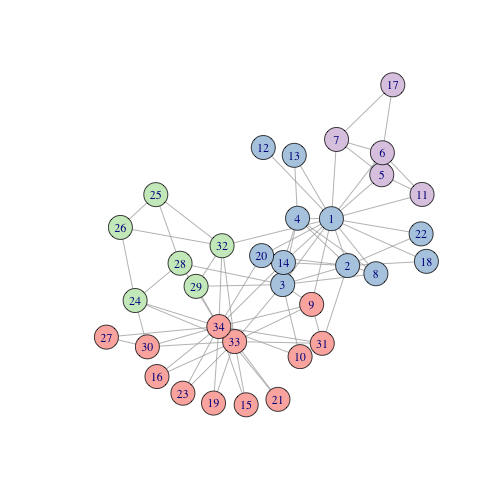

```r
library("igraph")
library("reticulate")
library("RColorBrewer")
node.cols <- brewer.pal(max(c(3, partition)),"Pastel1")[partition]
plot(G, vertex.color = node.cols, layout=layout_with_kk)
```

We can reproduce passing arguments in this manner as well.

```r
partition <- leiden(G, "CPMVertexPartition", resolution_parameter = 0.05, legacy = TRUE)













































































partition
```

```
#>  [1] 2 2 2 2 2 2 2 2 1 2 2 2 2 2 1 1 2 2 1 2 1 2 1 1 1 1 1 1 1 1 1 1 1 1
```

```r
table(partition)
```

```
#> partition
#>  1  2
#> 17 17
```

We can plot the result in R to show it in the network. This reproduces the example in the Python leidenalg documentation.

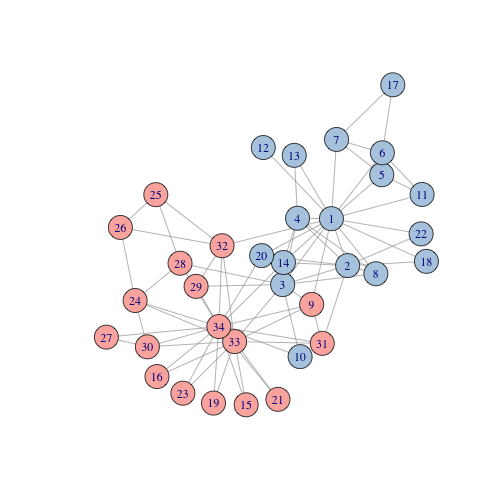

```r
node.cols <- brewer.pal(max(c(3, partition)),"Pastel1")[partition]
plot(G, vertex.color = node.cols, layout=layout_with_kk)
```

We can run the RBC vertex method which generalises the modularity vertex partition.

```r
partition <- leiden(G, "RBConfigurationVertexPartition", resolution_parameter = 1.5)













































































partition
```

```
#>  [1] 3 3 4 4 5 5 5 4 1 4 5 3 4 4 1 1 5 3 1 3 1 3 1 2 2 2 1 2 2 1 1 2 1 1
```

```r
table(partition)
```

```
#> partition
#>  1  2  3  4  5
#> 11  6  6  6  5
```

We can plot the result in R to show it in the network.

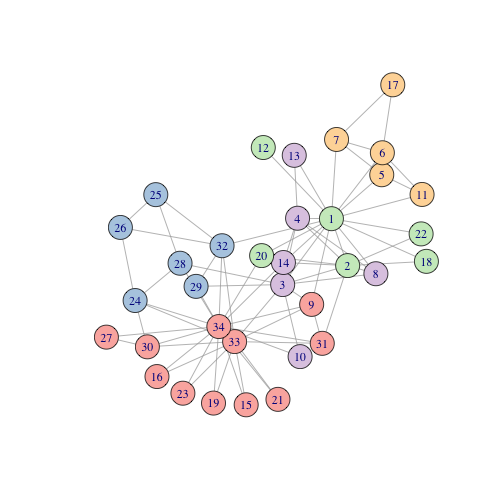

```r
node.cols <- brewer.pal(max(c(3, partition)),"Pastel1")[partition]
plot(G, vertex.color = node.cols, layout=layout_with_kk)
```

#### Calling C in R with igraph

We can improve performance for undirected graphs for Modularity and CPM cost functions by calling C in igraph.

```r
G <- as.undirected(G, mode = "each")
is.directed(G)
```

```
#> [1] FALSE
```

```r
partition <- leiden(G, "ModularityVertexPartition", legacy = FALSE)



partition
```

```
#>  [1] 1 1 1 1 2 2 2 1 3 3 2 1 1 1 3 3 2 1 3 1 3 1 3 4 4 4 3 4 4 3 3 4 3 3
```

```r
table(partition)
```

```
#> partition
#>  1  2  3  4
#> 11  5 12  6
```

We can plot the result in R to show it in the network. This reproduces the example in the Python leidenalg documentation.

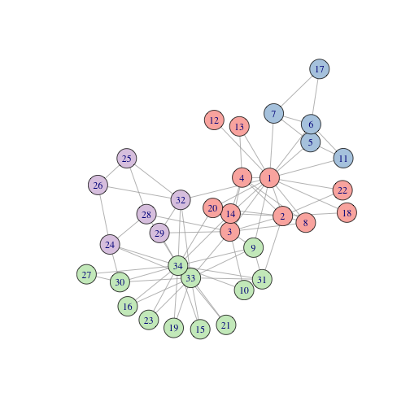

```r
library("igraph")
library("reticulate")
library("RColorBrewer")
node.cols <- brewer.pal(max(c(3, partition)),"Pastel1")[partition]
plot(G, vertex.color = node.cols, layout=layout_with_kk)
```

We check here that it returns the same results as in igraph.

```r
partition <- membership(cluster_leiden(G, objective_function = "modularity"))
partition
```

```
#>  [1] 1 1 1 1 2 2 2 1 3 3 2 1 1 1 3 3 2 1 3 1 3 1 3 4 4 4 3 4 4 3 3 4 3 3
```

```r
table(partition)
```

```
#> partition
#>  1  2  3  4
#> 11  5 12  6
```

We can also run CPM cost functions.

```r
partition <- leiden(G, "CPMVertexPartition", resolution_parameter = 0.1, legacy = FALSE)

partition
```

```
#>  [1] 1 1 1 1 2 2 2 1 3 4 2 5 1 1 3 3 2 1 3 1 3 1 3 3 3 3 3 3 3 3 3 3 3 3
```

```r
table(partition)
```

```
#> partition
#>  1  2  3  4  5
#> 10  5 17  1  1
```

We can plot the result in R to show it in the network. This reproduces the example in the Python leidenalg documentation.

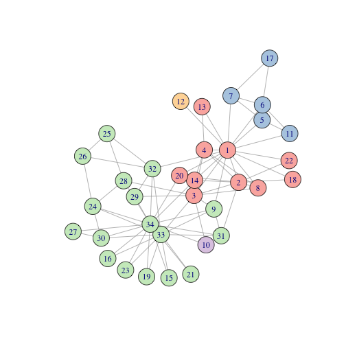

```r
node.cols <- brewer.pal(max(c(3, partition)),"Pastel1")[partition]
plot(G, vertex.color = node.cols, layout=layout_with_kk)
```

#### Benchmarking the R version with reticulate

```r
G <- graph.famous('Zachary')
summary(G)
```

```
#> IGRAPH 4a9bc31 U--- 34 78 -- Zachary
#> + attr: name (g/c)
```

```r
start <- Sys.time()
for(ii in 1:100){
  partition <- leiden(G, "ModularityVertexPartition", legacy = TRUE)
}























































































































































































































































































































































































































































































































































































































































































































































































































































































































































































































































































































































































































































































































































































































































































































































































































































































































































































































































































































































































































































































































































































































































































































































































































































































































































































































































































































































































































































































































































































































































































































































































































































































































































































































































































































































































































































































































































































































































































































































































































































































































































































































































































































































































































































































































































































































































































































































































































































































































































































































































































































































































































































































































































































































































































































































































































































































































































































































































































































































































































































































































































































































































































































































































































































































































































































































































































































































































































































































































































































































































































































































































































































































































































































































































































































































































































































































































































































































































































































































































































































































































end <- Sys.time()
table(partition)
```

```
#> partition
#>  1  2  3  4
#> 12 11  6  5
```

```r
R_graph_time = difftime(end, start)[[1]]
print(paste(c("leiden time:", R_graph_time, "seconds"), collapse = " "))
```

```
#> [1] "leiden time: 6.12171792984009 seconds"
```

We can see that the R reticualte implementation does not perform as well as the Python version but it is convenient for R users. Calling from a graph object avoids casting to a dense adjacency matrix which reduces memory load for large graph objects.

We can see that calling leiden in R on an adjacency matrix has faster performance but it does require more memory. For example, on a dense adjacency matrix:

```r
G <- graph.famous('Zachary')
summary(G)
```

```
#> IGRAPH 4e7d482 U--- 34 78 -- Zachary
#> + attr: name (g/c)
```

```r
start <- Sys.time()
for(ii in 1:100){
  adj_mat <- as_adjacency_matrix(G, sparse = FALSE)
}
end <- Sys.time()
dim(adj_mat)
```

```
#> [1] 34 34
```

```r
R_mat_cast_time = difftime(end, start)[[1]]
paste(print(c("cast time:", R_mat_cast_time, "seconds"), collapse = " "))
```

```
#> [1] "cast time:"         "0.0143280029296875" "seconds"
#> [1] "cast time:"         "0.0143280029296875" "seconds"
```

```r
start <- Sys.time()
for(ii in 1:100){
  partition <- leiden(adj_mat, "ModularityVertexPartition")
}




































































































end <- Sys.time()
table(partition)
```

```
#> partition
#>  1  2  3  4
#> 12 11  6  5
```

```r
R_mat_time = difftime(end, start)[[1]]
print(paste(c("leiden time:", R_mat_time, "seconds"), collapse = " "))
```

```
#> [1] "leiden time: 0.916937828063965 seconds"
```

For example, on a sparse dgCMatrix for the adjacency matrix:

```r
G <- graph.famous('Zachary')
summary(G)
```

```
#> IGRAPH f977ddc U--- 34 78 -- Zachary
#> + attr: name (g/c)
```

```r
start <- Sys.time()
for(ii in 1:100){
  adj_mat <- as_adjacency_matrix(G, sparse = TRUE)
}
end <- Sys.time()
class(adj_mat)
```

```
#> [1] "dgCMatrix"
#> attr(,"package")
#> [1] "Matrix"
```

```r
dim(adj_mat)
```

```
#> [1] 34 34
```

```r
R_sparse_mat_cast_time = difftime(end, start)[[1]]
paste(print(c("cast time:", R_sparse_mat_cast_time, "seconds"), collapse = " "))
```

```
#> [1] "cast time:"        "0.145066022872925" "seconds"
#> [1] "cast time:"        "0.145066022872925" "seconds"
```

```r
start <- Sys.time()
for(ii in 1:100){
  partition <- leiden(adj_mat, "ModularityVertexPartition")
}















```

[output not shown]

[output not shown]

[output not shown]

[output not shown]

[output not shown]

[output not shown]

[output not shown]

[output not shown]

[output not shown]

[output not shown]

[output not shown]

[output not shown]

[output not shown]

[output not shown]

[output not shown]

[output not shown]

[output not shown]

[output not shown]

[output not shown]

[output not shown]

[output not shown]

[output not shown]

[output not shown]

[output not shown]

[output not shown]

[output not shown]

[output not shown]

[output not shown]

[output not shown]

[output not shown]

[output not shown]

[output not shown]

[output not shown]

[output not shown]

[output not shown]

[output not shown]

[output not shown]

[output not shown]

[output not shown]

[output not shown]

[output not shown]

[output not shown]

[output not shown]

[output not shown]

[output not shown]

[output not shown]

[output not shown]

[output not shown]

[output not shown]

[output not shown]

[output not shown]

[output not shown]

[output not shown]

[output not shown]

[output not shown]

[output not shown]

[output not shown]

[output not shown]

[output not shown]

[output not shown]

[output not shown]

[output not shown]

[output not shown]

[output not shown]

[output not shown]

[output not shown]

[output not shown]

[output not shown]

[output not shown]

[output not shown]

[output not shown]

[output not shown]

[output not shown]